# The Effects of Covid-19 and Online Class on Grades at the University of Maryland

# Motivation

In response to Covid-19, in mid-spring 2020, UMD moved classes online and changed grading policies. This obiously had an effect on student grades during that semester, and we will attempt to quantify that effect here. We will compare historic grade data to the various permutations of online class that occured between spring 2020 and spring 2021. A we will soon see, it is clear that grades were inflated diring this time but the reason is not quite as clear. Some suggest it is due to the option of switching courses to be graded as pass/fail during some of those semesters, some think it is due to professors being lenient during the pandemic, while others point to the ease of cheating during online schooling.

### Data Collection

Most of the data will be collected from www.planetterp.com, a student run website that allows students to search for courses and professors to see grade data. Planetterp has an API that will allow us to collect the data.

First we will get a list of all courses offered at UMD from 2012-2022:

```python
import requests
import pandas as pd
import numpy as np
import planetterp

# get all courses.
# The API will not let us make queries for more than 100.
# We will use the offset flag in a loop to get all.
# How do we know when were done?
# By manual inspection, there are 13792 courses!

# loop, offessting by 100 from 0 to 13800 and append. this should get all!
all_courses1 = pd.DataFrame()
i = 0
curr_df = pd.json_normalize(requests.get(f"https://planetterp.com/api/v1/courses").json()) # default offset = 0, limit = 100. Convert to dataframe
while i < 13800:

    curr_df =  pd.json_normalize(requests.get(f"https://planetterp.com/api/v1/courses?offset={i}").json())
    all_courses1 = pd.concat([all_courses1, curr_df], ignore_index=True)
    i = i + 100
```

```python
# Query took a couple of minutes. Saving to csv so dont need to do again.
all_courses1.to_csv("all_courses_planetterp")
all_courses= pd.read_csv("all_courses_planetterp")
```

```python
all_courses.head()
```

|  | Unnamed: 0 | average_gpa | professors | department | course_number | name | title | credits | description | is_recent |
| --- | --- | --- | --- | --- | --- | --- | --- | --- | --- | --- |
| 0 | 0 | 3.728530 | ['Jordan Boyd-Graber', 'A Seyed', 'Vanessa Fri... | INST | 737 | INST737 | Introduction to Data Science | 3.0 | <b>Prerequisite:</b> INST627 and (LBSC690, LBS... | True |
| 1 | 1 | NaN | ['Aaron Goldman', 'Mark Hill', 'Robert DiLutis... | MUSC | 800W | MUSC800W | Advanced Seminar in Music Pedagogy | 3.0 | <b>Prerequisite:</b> MUSC400; or students who ... | True |
| 2 | 2 | 3.407091 | ['Qin Wang', 'Abani Pradhan', 'Solmaz Alborzi'... | NFSC | 112 | NFSC112 | Food: Science and Technology | 3.0 | Introduction to the realm of food science, foo... | True |
| 3 | 3 | 3.923333 | ['Abani Pradhan', 'Abani Pradhan', 'Abani Prad... | NFSC | 679R | NFSC679R | Selected Topics in Food Science; Food Safety a... | 4.0 | NaN | True |
| 4 | 4 | 2.300000 | ['Emily Perez', 'Laura Williams', 'Douglas Ker... | AASP | 298L | AASP298L | African-American Literature and Culture | 3.0 | <b>Cross-listed with:</b> ENGL234.\n<b>Credit ... | True |

Now that we have all of the courses, we will need to get all of the grades as well.

```python
# end goal: be able to break down grades by semester to compare online vs in person grades.
all_grades = pd.DataFrame()
for name in all_courses["name"]:
    curr_grades =  pd.json_normalize(requests.get(f"https://planetterp.com/api/v1/grades?course={name}").json())
    all_grades = pd.concat([all_grades, curr_grades], ignore_index=True)
```

```python
# Requests took ~45 minutes. saving as csv so never have to do it again. Next time I will consider a multithreaded approach to speed this up
 all_grades.to_csv("all_grades_ever_planetterp")
```

```python
all_grades = pd.read_csv("all_grades_ever_planetterp")
```

```python
all_grades.head()
```

|  | Unnamed: 0 | course | professor | semester | section | A+ | A | A- | B+ | B | B- | C+ | C | C- | D+ | D | D- | F | W | Other |
| --- | --- | --- | --- | --- | --- | --- | --- | --- | --- | --- | --- | --- | --- | --- | --- | --- | --- | --- | --- | --- |
| 0 | 0 | INST737 | Jordan Boyd-Graber | 201301 | 0101 | 4 | 8 | 4 | 4 | 2 | 0 | 0 | 1 | 0 | 0 | 0 | 0 | 0 | 4 | 6 |
| 1 | 1 | INST737 | Jordan Boyd-Graber | 201401 | 0101 | 9 | 7 | 6 | 4 | 3 | 1 | 0 | 0 | 0 | 0 | 0 | 0 | 0 | 1 | 0 |
| 2 | 2 | INST737 | NaN | 201408 | 0101 | 6 | 13 | 6 | 6 | 0 | 0 | 0 | 0 | 0 | 0 | 0 | 0 | 0 | 1 | 0 |
| 3 | 3 | INST737 | NaN | 201501 | SG01 | 2 | 4 | 0 | 2 | 0 | 0 | 0 | 0 | 0 | 0 | 0 | 0 | 0 | 1 | 0 |
| 4 | 4 | INST737 | A Seyed | 201508 | 0101 | 18 | 9 | 0 | 1 | 0 | 0 | 0 | 0 | 0 | 0 | 0 | 0 | 0 | 0 | 0 |

Here we will collect the total number of students who took each course.

```python
# add a column for the total number of grades reported per class. This number is equal to the total students
all_grades["total_students"] = (all_grades["A+"] + all_grades["A"] + all_grades["A-"] +
                                all_grades["B+"] + all_grades["B"] + all_grades["B-"] +
                                all_grades["C+"] + all_grades["C"] + all_grades["C-"] +
                                all_grades["D+"] + all_grades["D"] +all_grades["D-"] +
                                all_grades["F"] + all_grades["Other"] + all_grades["W"])
```

```python
# handle missing values. with so many values, we will drop rows with null values.
all_grades.replace('', np.NaN, inplace=True)
all_grades.dropna(inplace=True)
```

Note that the total number of students who take the course is not the same as those who will end with a letter grade on their transcript at the end of the semester for one reason or another. This will be important later.

```python
# add a column for all students who are taking the class as graded. UMD does not count Other or W towards gpa
all_grades["total_students_graded"] = all_grades["total_students"] - all_grades["Other"] - all_grades["W"]
```

Calculate the GPA for each course. We will use the weights for each grade provided at: https://www.testudo.umd.edu/gpa/index.html

```python
# Add a column for the gpa of the course. Weights taken from UMD website
all_grades["gpa"] = ((all_grades["A+"] + all_grades["A"]) * 4.0 +
                     all_grades["A-"] * 3.7 +
                     all_grades["B+"] * 3.3 +
                     all_grades["B"] * 3.0 +
                     all_grades["B-"] * 2.7 +
                     all_grades["C+"] *2.3 +
                     all_grades["C"] * 2.0 +
                     all_grades["C-"] * 1.7 +
                     all_grades["D+"] * 1.3 +
                     all_grades["D"] * 1.0 +
                     all_grades["D-"] * .7 +
                     all_grades["F"] *0)/all_grades["total_students_graded"]
```

```python
# remove gpas with value of 0.
all_grades['gpa'].replace(0, np.NaN, inplace=True)
all_grades.dropna(inplace=True)
```

```python
all_grades.drop("Unnamed: 0", axis=1,inplace=True)
```

Here we will convert the semester data from the form YYYYMM to YYYY.0 for spring and YYYY.5 for fall. This Will be useful when we want to visualize the data.

```python
all_grades["semester"] = np.where((all_grades["semester"]% 100 == 1), (all_grades["semester"].floordiv(100)), all_grades["semester"] )
all_grades["semester"] = np.where((all_grades["semester"] % 100 == 8), (all_grades["semester"].floordiv(100) + .5), all_grades["semester"] )
```

```python
all_grades.head()
```

|  | course | professor | semester | section | A+ | A | A- | B+ | B | B- | ... | C- | D+ | D | D- | F | W | Other | total_students | total_students_graded | gpa |
| --- | --- | --- | --- | --- | --- | --- | --- | --- | --- | --- | --- | --- | --- | --- | --- | --- | --- | --- | --- | --- | --- |
| 0 | INST737 | Jordan Boyd-Graber | 2013.0 | 0101 | 4 | 8 | 4 | 4 | 2 | 0 | ... | 0 | 0 | 0 | 0 | 0 | 4 | 6 | 33 | 23 | 3.652174 |
| 1 | INST737 | Jordan Boyd-Graber | 2014.0 | 0101 | 9 | 7 | 6 | 4 | 3 | 1 | ... | 0 | 0 | 0 | 0 | 0 | 1 | 0 | 31 | 30 | 3.703333 |
| 4 | INST737 | A Seyed | 2015.5 | 0101 | 18 | 9 | 0 | 1 | 0 | 0 | ... | 0 | 0 | 0 | 0 | 0 | 0 | 0 | 28 | 28 | 3.975000 |
| 5 | INST737 | A Seyed | 2016.0 | 0101 | 20 | 5 | 0 | 0 | 0 | 0 | ... | 0 | 0 | 0 | 0 | 0 | 0 | 0 | 25 | 25 | 4.000000 |
| 6 | INST737 | Vanessa Frias-Martinez | 2016.0 | SG01 | 4 | 11 | 9 | 0 | 0 | 0 | ... | 0 | 0 | 0 | 0 | 0 | 0 | 0 | 24 | 24 | 3.887500 |

5 rows × 22 columns

```python
# get the avg total grades for all courses for each semester.
avg_sem_grades = (all_grades.groupby("semester")).mean().reset_index()
```

### Visualization

Now that we have our data, we can begin to visualize it. We will start a basic graph of GPA over time.

```python
import seaborn as sns
import matplotlib.pyplot as plt
import matplotlib.dates as mdates
```

```
[(0.0, 4.0)]
```

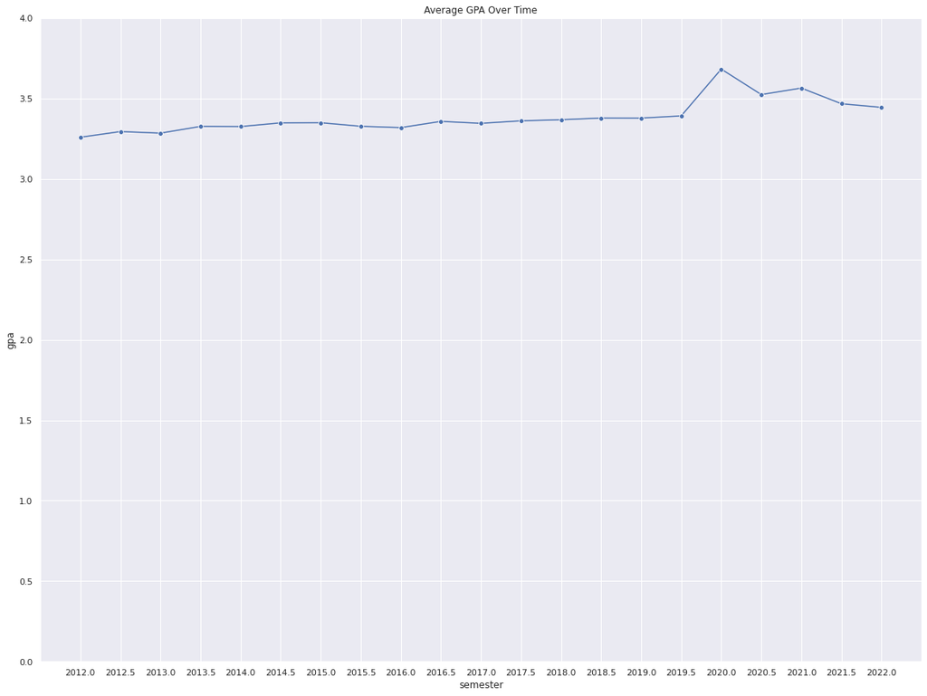

```python
# plot average gpa over time.
sns.set(rc={'figure.figsize':(20, 15)})
ax = sns.lineplot(x=avg_sem_grades["semester"], y=avg_sem_grades["gpa"], data = avg_sem_grades, marker='o')
ax.set(title = "Average GPA Over Time")
ax.set(xticks=avg_sem_grades.semester)
ax.set(ylim=[0,4.0])
```

## Question: What factors caused this inflation?

As expected, there was a huge spike when school went online for covid! Grades remained higher than average for the next three semesters although less so. The following potential reasons come to mind:

1. UMD allowed taking a class pass/fail during some of these semesters. Students with lower grades likely opted for a pass rather than a below average grade.
2. Students took advantage of online assessments (cheating).
3. Teachers were more lenient during this time due to the difficulty and stresses of the pandemic.

### Option 1: The pass/fail option inflated grades

First let's try to see how much the pass fail option increased grades.

##### But what should we consider average grade? And how many Other grades should we replace?

For this we will look to historical data. For each course, we will find the historical average GPA and amount of Other grades. Since pass/fail was not an option in previous semesters, we can subtract this average from the covid Other numbers and assume these are the passes.

##### What about Grade Inflation?

As you can see, even prior to 2020, there is an overall upward trend of GPAs. We will have to factor this in to our analysis as well. We will begin here to get the baseline rate of grade inflation using a linear regression.

```python
from sklearn.linear_model import LinearRegression
import numpy as np
import matplotlib.pyplot as plt
from sklearn.metrics import r2_score
```

```python
# collect pre_pandemic grades
pre_pandemic = all_grades.loc[all_grades["semester"]< 2020.0]
```

```python
# train and fit model
model = LinearRegression()
x= np.array(pre_pandemic["semester"]).reshape(-1,1)
y=pre_pandemic["gpa"]
#x= np.array(pre_pandemic["semester"]).reshape(-1,1)
model.fit(x, y)
```

```
LinearRegression()
```

```python
print('intercept:', model.intercept_)
print('slope:', model.coef_[0])
```

```
intercept: -24.786339065091198
slope: 0.013952405483758732
```

Based on the slope above we see that GPA increases by ~.014 points per year. We will now evaluate this regression

```python
y_pred = []
for i in np.arange(2012, 2020, .5):
    y_pred = y_pred + [( model.intercept_ +  (model.coef_[0] * i))]
```

```python
r2_score((pre_pandemic.groupby("semester").mean()['gpa']), y_pred)
```

```
0.8244585645677049
```

Our model has an R^2 value of .82, showing that our line should fit the data pretty well. Let's plot it to see how we did.

```python
def abline(slope, intercept, ax, xlim):
    """Plot a line from slope and intercept"""
    axes = ax
    x_vals = np.array(xlim)

    y_vals = intercept + slope * x_vals
    ax.set(xlim=(2012, 2022.5))
    plt.plot(x_vals, y_vals, '--')
```

```
[(0.0, 4.0)]
```

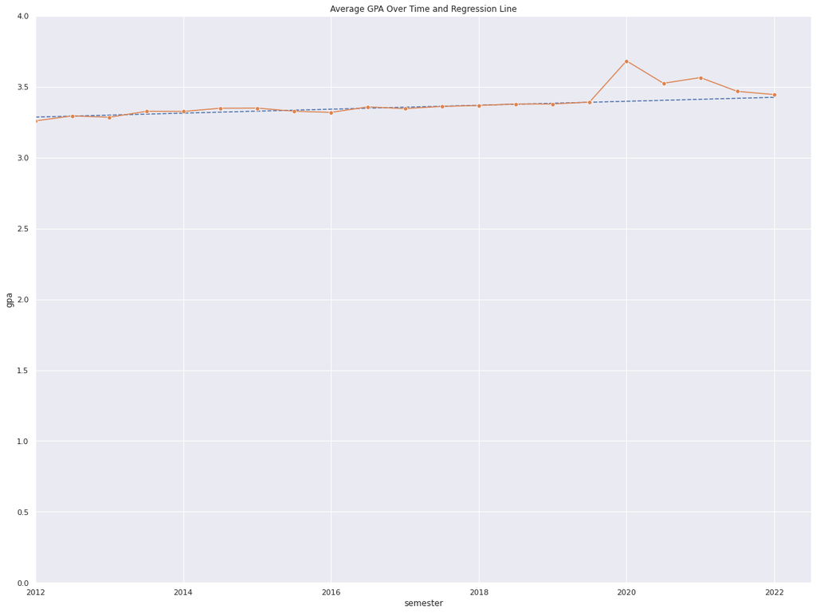

```python
fig, ax = plt.subplots()
abline(model.coef_[0],model.intercept_,  ax, [2012, 2022])
sns.lineplot(x=avg_sem_grades["semester"], y=avg_sem_grades["gpa"], data = avg_sem_grades, marker='o', ax=ax)

ax.set(title="Average GPA Over Time and Regression Line")
ax.set(ylim= (0,4))
```

Note that we have extended the regression line to show where we would have expected GPA to be once the pandemic hit. Grades were back to there expected levels in spring 2022

First, a couple notes about online class and pass/fail grading during this time:

On to the normalization:

```python
# add a column for pass fail data
all_grades["pass_fail"] = (all_grades["semester"] == 2020) | (all_grades["semester"] == 2021)
```

```python
# and for online classes
all_grades["online"] = (all_grades["semester"] == 2020) | (all_grades["semester"] == 2021) | (all_grades["semester"] == 2021.5)
```

```python
all_grades["normalized_gpa"] = all_grades["gpa"]
```

```python
all_grades=all_grades.reset_index();
```

```python
# get percent of other grading
all_grades['other_pct'] = all_grades['Other']/all_grades['total_students']
pre_pandemic['other_pct'] = pre_pandemic['Other']/pre_pandemic['total_students']
```

```python
# Group, average and merge
all_grades = pd.merge(all_grades, (pd.DataFrame(pre_pandemic.groupby("course")['gpa'].quantile(.25)).reset_index().rename(columns = {'gpa': 'historic_lower'})), on='course')
all_grades = pd.merge(all_grades, (pd.DataFrame(pre_pandemic.groupby("course")['other_pct'].mean()).reset_index().rename(columns = {'other_pct': 'historic_other'})), on='course')
```

```python
pass_fail_sems = all_grades.loc[(all_grades['pass_fail'] == True)].reset_index()
```

```python
pass_fail_sems.head()
```

|  | level_0 | index | course | professor | semester | section | A+ | A | A- | B+ | ... | total_students | total_students_graded | gpa | date | pass_fail | online | normalized_gpa | other_pct | historic_lower | historic_other |
| --- | --- | --- | --- | --- | --- | --- | --- | --- | --- | --- | --- | --- | --- | --- | --- | --- | --- | --- | --- | --- | --- |
| 0 | 11 | 13 | INST737 | Vanessa Frias-Martinez | 2020.0 | 0101 | 0 | 13 | 0 | 0 | ... | 19 | 13 | 4.000000 | 2020-01-01 | True | True | 4.000000 | 0.315789 | 3.846528 | 0.028387 |
| 1 | 160 | 162 | ENGL101H | Steve Beaulieu | 2020.0 | 0408 | 0 | 6 | 1 | 0 | ... | 14 | 8 | 3.837500 | 2020-01-01 | True | True | 3.837500 | 0.428571 | 3.436842 | 0.004055 |
| 2 | 168 | 170 | ENGL101H | Katherine Joshi | 2021.0 | 0408 | 1 | 3 | 1 | 1 | ... | 6 | 6 | 3.833333 | 2021-01-01 | True | True | 3.833333 | 0.000000 | 3.436842 | 0.004055 |
| 3 | 217 | 219 | ENGL234 | Mike Kolakoski | 2020.0 | 0101 | 6 | 5 | 2 | 3 | ... | 27 | 18 | 3.572222 | 2020-01-01 | True | True | 3.572222 | 0.185185 | 2.638810 | 0.004859 |
| 4 | 218 | 220 | ENGL234 | Andy Yeh | 2020.0 | 0201 | 2 | 12 | 1 | 2 | ... | 24 | 19 | 3.489474 | 2020-01-01 | True | True | 3.489474 | 0.125000 | 2.638810 | 0.004859 |

5 rows × 31 columns

Here we will calculate the "Normalized" GPA for the pass/fail semesters. This is calculated as follows:

```python
pass_fail_sems['normalized_gpa'] = None
```

```python
pass_fail_sems['normalized_gpa'] = ( ((pass_fail_sems.Other - (pass_fail_sems.historic_other * pass_fail_sems.total_students)) #expected number of non-Other students
                                    * (pass_fail_sems.historic_lower * (1+model.coef_[0])) # inflation adjusted historic quartile
                                    + pass_fail_sems['gpa']*pass_fail_sems.total_students_graded)

                                    / ((pass_fail_sems.Other - (pass_fail_sems.historic_other * pass_fail_sems.total_students)) #expected number of non-Other students
                                    + pass_fail_sems.total_students_graded))
```

```python
pass_fail_sems_avgs = pass_fail_sems.groupby("semester").mean().reset_index() # get the avergage gpa for these semesters
```

Now that we added a Normalized GPA, we can see how much pass fail option effected grades

```
[(0.0, 4.0)]
```

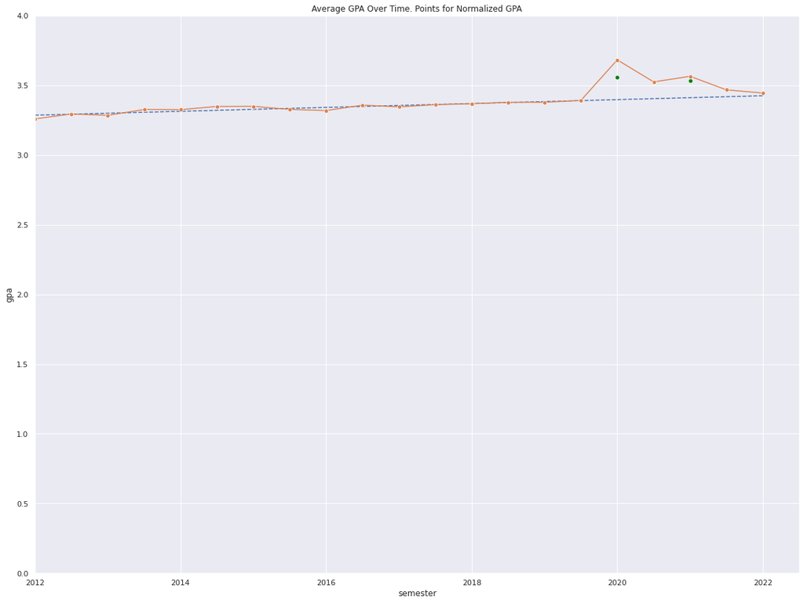

```python
fig, ax = plt.subplots()
#sns.regplot(x= (pre_pandemic["semester"]), y= pre_pandemic["gpa"], scatter=False, ax=ax)
abline(model.coef_[0],model.intercept_,  ax, [2012, 2022])
sns.lineplot(x=avg_sem_grades["semester"], y=avg_sem_grades["gpa"], data = avg_sem_grades, marker='o', ax=ax)
sns.scatterplot(x=pass_fail_sems_avgs["semester"], y=pass_fail_sems_avgs["normalized_gpa"], data = pass_fail_sems_avgs, marker='o', ax=ax, color ='green')
ax.set(title= "Average GPA Over Time. Points for Normalized GPA")
ax.set(ylim= (0,4))
```

Okay, so this brought the averages down closer to baseline, although not all the way. As expected, the effect was greater in 2020 than 2021.

Notice however that the normalized GPA for both semesters is very close the average GPA in fall 2020. This suggests that we have successfully removed the role of pass/fail from the inflated grades and that there is another common factor contributing to grade inflation.

### Option 2: Cheating

This one is more difficult to quantify, although we will make an attempt. The assumtion we will make here is that courses that have answers readily available on the internet and are mostly exam focused will be easier to cheat in. Courses that generally require original work without clear answers will be more dificult to cheat in.

Based on these assumptions we will analyze the grades of English, Mathematics and Computer Science.

If our hypothesis is correct, Math will have a very high jump in grades, English will have one relatively lower, and Computer Science will be somewhere in between where answers can be found online but courses tend to be project based.

First we will separate out the department from the courses.

```python
pass_fail_sems['dept'] = pass_fail_sems['course'].str.extract('([a-zA-Z]+)', expand=True)
all_grades['dept'] = all_grades['course'].str.extract('([a-zA-Z]+)', expand=True)
```

```python
pass_fail_sems['number'] = pass_fail_sems['course'].str.extract('([0-9]+$)', expand=True)
all_grades['number'] = all_grades['course'].str.extract('([0-9]+$)', expand=True)
```

```python
department_list=['MATH', 'ENGL', 'CMSC']
```

```python
avgs= all_grades.groupby(['dept', 'semester']).mean().reset_index()
```

```python
df = avgs.loc[avgs['dept'].isin(department_list)]
```

```
[(2012.0, 2022.0)]
```

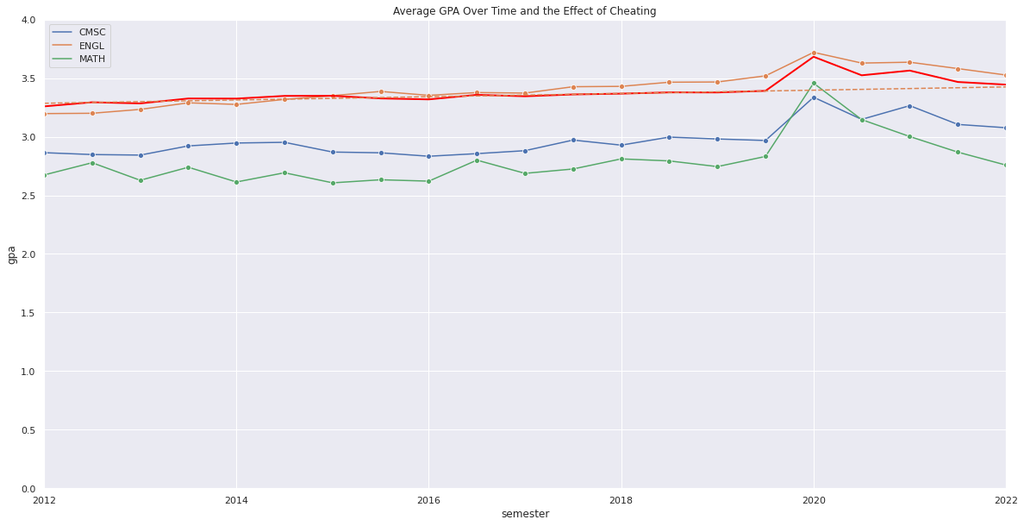

```python
import seaborn as sns
sns.set(rc={'figure.figsize':(20, 10)})
ax = sns.lineplot(x=avgs["semester"], y=avgs["gpa"], data =df, hue="dept", marker='o')
ax = sns.lineplot(x=avg_sem_grades["semester"], y=avg_sem_grades["gpa"], data =avg_sem_grades, lw=2, color = 'red')

abline(model.coef_[0],model.intercept_,  ax, [2012, 2022])

ax.set(title= 'Average GPA Over Time and the Effect of Cheating')

ax.set(ylim=[0,4.0])
ax.set(xlim=[2012,2022])
```

Note that in the graph above, the average for all grades is red and the regression line is dotted orange.

Our hypothesis seems to hold! English had the lowest spike in grades in 2020 followed by Computer Science, and by Math.

#### Contact

Please reach out if you have any comments or questions regarding this analysis.

rafikap@gmail.com